# Introduction to data reporting with Python

Guardian Visuals

7 December, 2022

Workbook 👉 bit.ly/gv-python

## Wherefore?

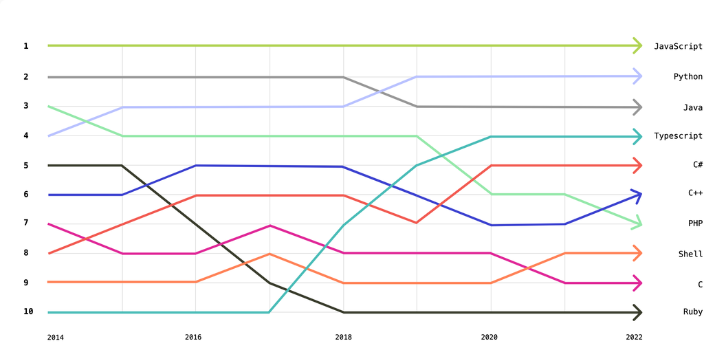

## Python is:

- Powerful
- Popular
- Portable
- Paradigmatic

## 🥅 Goals

1. Introducing JupyterLab/basic data visualisation using Altair
2. Workflow for private collaborative data reporting
3. Introducing kepler.gl for geospatial visualisation

## 📊 Introducing JupyterLab/basic Python data visualisation using Altair

- 📺 [Intro to Jupyter](https://youtu.be/A5YyoCKxEOU)
- 📺 [Intro to code cells](https://youtu.be/A5YyoCKxEOU?t=281)

```python
# I'm a code cell. Type Shift-Enter to execute me!

x = 42

print(x)
```

```python
# I'm a code cell. Type Shift-Enter to execute me!

x = 42

print(x)
```

```
42
```

### Load example data

```python
from vega_datasets import data

df_cars = data.cars()

print(data.cars.description)

df_cars
```

```python
from vega_datasets import data

df_cars = data.cars()

print(data.cars.description)

df_cars
```

```
Acceleration, horsepower, fuel efficiency, weight, and other characteristics of different makes and models of cars. This dataset was originally published by Donoho et al (1982) [1]_, and was made public at http://lib.stat.cmu.edu/datasets/
```

|  | Name | Miles_per_Gallon | Cylinders | Displacement | Horsepower | Weight_in_lbs | Acceleration | Year | Origin |
| --- | --- | --- | --- | --- | --- | --- | --- | --- | --- |
| 0 | chevrolet chevelle malibu | 18.0 | 8 | 307.0 | 130.0 | 3504 | 12.0 | 1970-01-01 | USA |
| 1 | buick skylark 320 | 15.0 | 8 | 350.0 | 165.0 | 3693 | 11.5 | 1970-01-01 | USA |
| 2 | plymouth satellite | 18.0 | 8 | 318.0 | 150.0 | 3436 | 11.0 | 1970-01-01 | USA |
| 3 | amc rebel sst | 16.0 | 8 | 304.0 | 150.0 | 3433 | 12.0 | 1970-01-01 | USA |
| 4 | ford torino | 17.0 | 8 | 302.0 | 140.0 | 3449 | 10.5 | 1970-01-01 | USA |
| ... | ... | ... | ... | ... | ... | ... | ... | ... | ... |
| 401 | ford mustang gl | 27.0 | 4 | 140.0 | 86.0 | 2790 | 15.6 | 1982-01-01 | USA |
| 402 | vw pickup | 44.0 | 4 | 97.0 | 52.0 | 2130 | 24.6 | 1982-01-01 | Europe |
| 403 | dodge rampage | 32.0 | 4 | 135.0 | 84.0 | 2295 | 11.6 | 1982-01-01 | USA |
| 404 | ford ranger | 28.0 | 4 | 120.0 | 79.0 | 2625 | 18.6 | 1982-01-01 | USA |
| 405 | chevy s-10 | 31.0 | 4 | 119.0 | 82.0 | 2720 | 19.4 | 1982-01-01 | USA |

406 rows × 9 columns

### An interactive graphic in three four a few lines of code

```python
import altair as alt

alt.Chart(df_cars).mark_circle().encode(
    x="Horsepower",  # X axis variable!
    y="Miles_per_Gallon",  # Y axis variable!
    color="Origin",  # Colour variable!
)
```

```python
import altair as alt

alt.Chart(df_cars).mark_circle().encode(
    x="Horsepower",  # X axis variable!
    y="Miles_per_Gallon",  # Y axis variable!
    color="Origin",  # Colour variable!
)
```

[interactive chart not shown]

```python
import altair as alt

alt.Chart(df_cars).mark_circle().encode(
    x="Horsepower",
    y="Miles_per_Gallon",
    color="Origin",
    tooltip=["Name", "Origin", "Horsepower", "Miles_per_Gallon"],
)
```

```python
import altair as alt

alt.Chart(df_cars).mark_circle().encode(
    x="Horsepower",
    y="Miles_per_Gallon",
    color="Origin",
    tooltip=["Name", "Origin", "Horsepower", "Miles_per_Gallon"],
)
```

[interactive chart not shown]

```python
import altair as alt

alt.Chart(df_cars).mark_circle(size=60).encode(
    x="Horsepower",
    y="Miles_per_Gallon",
    color="Origin",
    tooltip=["Name", "Origin", "Horsepower", "Miles_per_Gallon"],
).interactive()  # Add interactivity
```

[interactive chart not shown]

### altair-viz.github.io/gallery/index.html

Try recreating one or two of the Altair examples in your workbook. Many of them use vega_datasets for their example data.

[figure not shown]

## 👩‍💻👨‍💻 Workflow for private collaborative data reporting

### Create a secret gist

1. Login to github.com (github.com/login).
2. Click the plus menu in the top right corner then ‘New gist’.

[figure not shown]

3. In the text box where it says ‘Filename including extension…’, give your gist the filename `ira-users-hashed.csv`. **The filename must end in .csv for it to format correctly on GitHub.**
4. Open your local copy of `ira-users-hashed.csv` in whichever of the text editors on your machine you like (you should find that Atom, Sublime Text and Visual Studio Code are all installed). Select the entire contents of the file (Command-A) then copy them to the clipboard (Command-C).
5. Paste the contents of the file into the text box (where there's a `1`).

[figure not shown]

1. Click ‘Create secret gist’. You should see some nicely formatted data!
2. Click the ‘Raw’ button to navigate to the plain text URL of your new gist and copy the URL to the clipboard.

[figure not shown]

### Load data using pandas

Data 👉 bit.ly/ira-users-hashed

```python
import pandas as pd

df_twitter = pd.read_csv("https://bit.ly/ira-users-hashed")

df_twitter.head()
```

```python
import pandas as pd

df_twitter = pd.read_csv("https://bit.ly/ira-users-hashed")

df_twitter.head()
```

|  | userid | tweet_count | days_active | account_language |
| --- | --- | --- | --- | --- |
| 0 | 004c1875a5f3a8ddfd2044b857a81c5d458882ac5cdf67... | 1342 | 1592 | en |
| 1 | 005b6c0f7e3371b1cacced2890fead3d5543694ab21372... | 101 | 1518 | en |
| 2 | 005c20d3604f7b90f0d5b22f60226d60cfd9c7bdf5c728... | 2 | 900 | en |
| 3 | 00b6194ca3359e2f37000037e20223ee91cfffcf15c7b9... | 86 | 1785 | ru |
| 4 | 00bd49f19d4096b1f47e6e7702dddd746cf7021795f234... | 538 | 1600 | en |

### Inspect with pandas-profiling

```python
from pandas_profiling import ProfileReport

profile  = ProfileReport(df_twitter, minimal=True)

profile.to_widgets()
```

### Reverse-engineer account creation date

```python
df_twitter["date_created"] = df_twitter["days_active"].apply(
    lambda d: pd.to_datetime("2018-10-01") - pd.DateOffset(days=d)
)

df_twitter.head()
```

```python
df_twitter["date_created"] = df_twitter["days_active"].apply(
    lambda d: pd.to_datetime("2018-10-01") - pd.DateOffset(days=d)
)

df_twitter.head()
```

|  | userid | tweet_count | days_active | account_language | date_created |
| --- | --- | --- | --- | --- | --- |
| 0 | 004c1875a5f3a8ddfd2044b857a81c5d458882ac5cdf67... | 1342 | 1592 | en | 2014-05-23 |
| 1 | 005b6c0f7e3371b1cacced2890fead3d5543694ab21372... | 101 | 1518 | en | 2014-08-05 |
| 2 | 005c20d3604f7b90f0d5b22f60226d60cfd9c7bdf5c728... | 2 | 900 | en | 2016-04-14 |
| 3 | 00b6194ca3359e2f37000037e20223ee91cfffcf15c7b9... | 86 | 1785 | ru | 2013-11-11 |
| 4 | 00bd49f19d4096b1f47e6e7702dddd746cf7021795f234... | 538 | 1600 | en | 2014-05-15 |

### Plot using Altair

```python
alt.Chart(df_twitter).mark_circle(size=60).encode(
    x="date_created:T",
    y="tweet_count:Q",
    color="account_language:N",
    tooltip=["date_created", "tweet_count", "account_language"],
).interactive().properties(width=600, height=400)
```

```python
alt.Chart(df_twitter).mark_circle(size=60).encode(
    x="date_created:T",
    y="tweet_count:Q",
    color="account_language:N",
    tooltip=["date_created", "tweet_count", "account_language"],
).interactive().properties(width=600, height=400)
```

[interactive chart not shown]

## 🗺 Introducing kepler.gl for geospatial visualisation

### Load data using pandas

```python
import pandas as pd

df_ghosn = pd.read_csv("http://bit.ly/flight-data")

df_ghosn.info()
df_ghosn.head()
```

```python
import pandas as pd

df_ghosn = pd.read_csv("http://bit.ly/flight-data")

df_ghosn.info()
df_ghosn.head()
```

```
<class 'pandas.core.frame.DataFrame'>
RangeIndex: 583065 entries, 0 to 583064
Data columns (total 4 columns):
 #   Column        Non-Null Count   Dtype
---  ------        --------------   -----
 0   time          583065 non-null  object
 1   lat           583065 non-null  float64
 2   lon           583065 non-null  float64
 3   baroaltitude  568720 non-null  float64
dtypes: float64(3), object(1)
memory usage: 17.8+ MB
```

|  | time | lat | lon | baroaltitude |
| --- | --- | --- | --- | --- |
| 0 | 2018-01-03 14:24:25 | -22.898529 | -43.409929 | 3695.70 |
| 1 | 2018-01-03 14:24:26 | -22.898529 | -43.409929 | 3695.70 |
| 2 | 2018-01-03 14:24:27 | -22.898529 | -43.409929 | 3695.70 |
| 3 | 2018-01-03 14:24:28 | -22.898529 | -43.409929 | 3749.04 |
| 4 | 2018-01-03 14:24:29 | -22.905191 | -43.411967 | 3771.90 |

### Create empty map

```python
from keplergl import KeplerGl

kepler_map = KeplerGl(height=600)
config = {
    "version": "v1",
    "config": {
        "mapState": {
            "latitude": 29.9511,
            "longitude": -90.0715,
            "zoom": 5,
        }
    }
}
kepler_map.config = config

kepler_map
```

`User Guide: https://github.com/keplergl/kepler.gl/blob/master/docs/keplergl-jupyter/user-guide.md`

[figure not shown]

### Add data to map

```python
kepler_map.add_data(
    data=df_ghosn.query("baroaltitude == baroaltitude"),
    name="Ghosn",
)

kepler_map
```

[figure not shown]

### Save map to HTML

```python
kepler_map.save_to_html(
    data={"Ghosn transponder data": df_ghosn},
    config=config,
    file_name="kepler_map.html",
)
```

`Map saved to kepler_map.html!`

1. Click on the Jupyter logo in the top left corner to see all the files in the current project (just click yes if it asks you if you're sure).
2. Click on `kepler_map.html`.

[figure not shown]

## 🤓 Further reading

- [First Python Notebook](https://palewi.re/docs/first-python-notebook/) (online course by Ben Welsh of LAT)
- [Python for Data Analysis, 3rd Edition](https://wesmckinney.com/book/) - Wes McKinney
- [Interviewing your data, visually, in Python](https://github.com/aplayford/nicar17-python-dataviz/blob/master/final_presentation.ipynb) (workshop by Adam Playford and Nat Lash)
- [The Turing Way](https://the-turing-way.netlify.app/welcome.html) (handbook for reproducible, ethical and collaborative data science)